# HW1

Arefeva Anna

05 11 2023

#Загрузка датасета

```r
data <- read.csv("insurance_cost.csv", stringsAsFactors = TRUE)
```

#Выведите гистограммы всех нумерических переменных

```
## 'data.frame':    1338 obs. of  7 variables:
##  $ age     : int  19 18 28 33 32 31 46 37 37 60 ...
##  $ sex     : Factor w/ 2 levels "female","male": 1 2 2 2 2 1 1 1 2 1 ...
##  $ bmi     : num  27.9 33.8 33 22.7 28.9 ...
##  $ children: int  0 1 3 0 0 0 1 3 2 0 ...
##  $ smoker  : Factor w/ 2 levels "no","yes": 2 1 1 1 1 1 1 1 1 1 ...
##  $ region  : Factor w/ 4 levels "northeast","northwest",..: 4 3 3 2 2 3 3 2 1 2 ...
##  $ charges : num  16885 1726 4449 21984 3867 ...
```

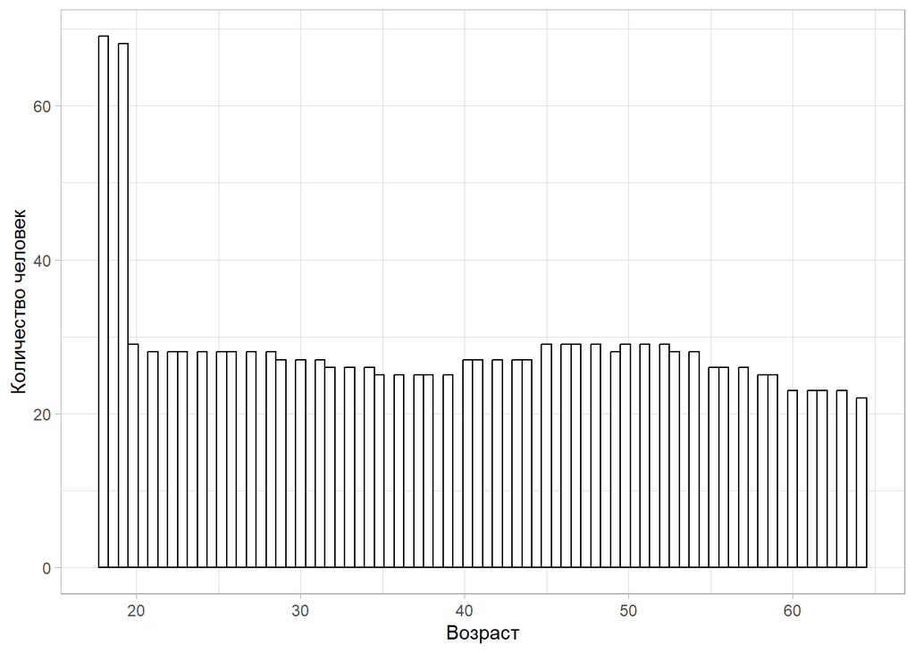

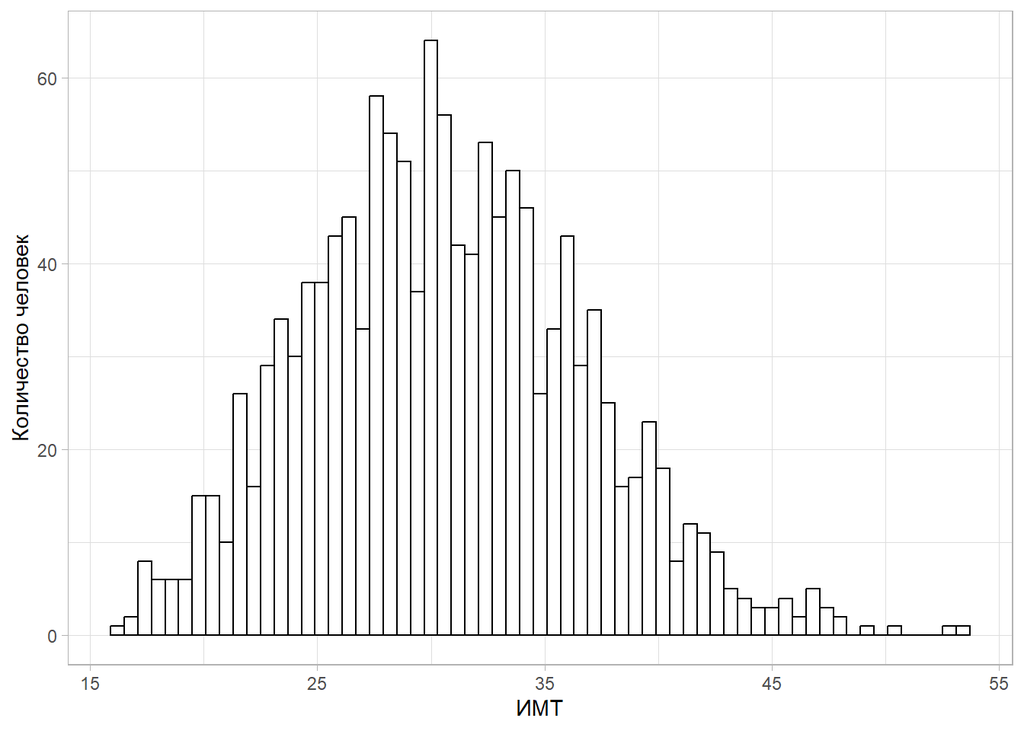

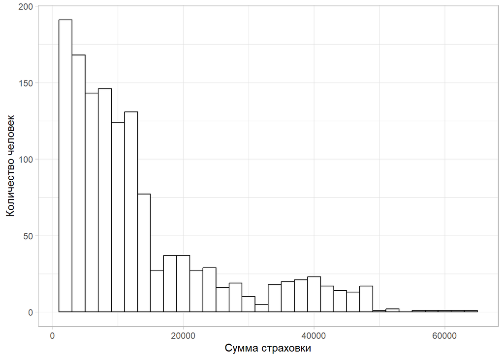

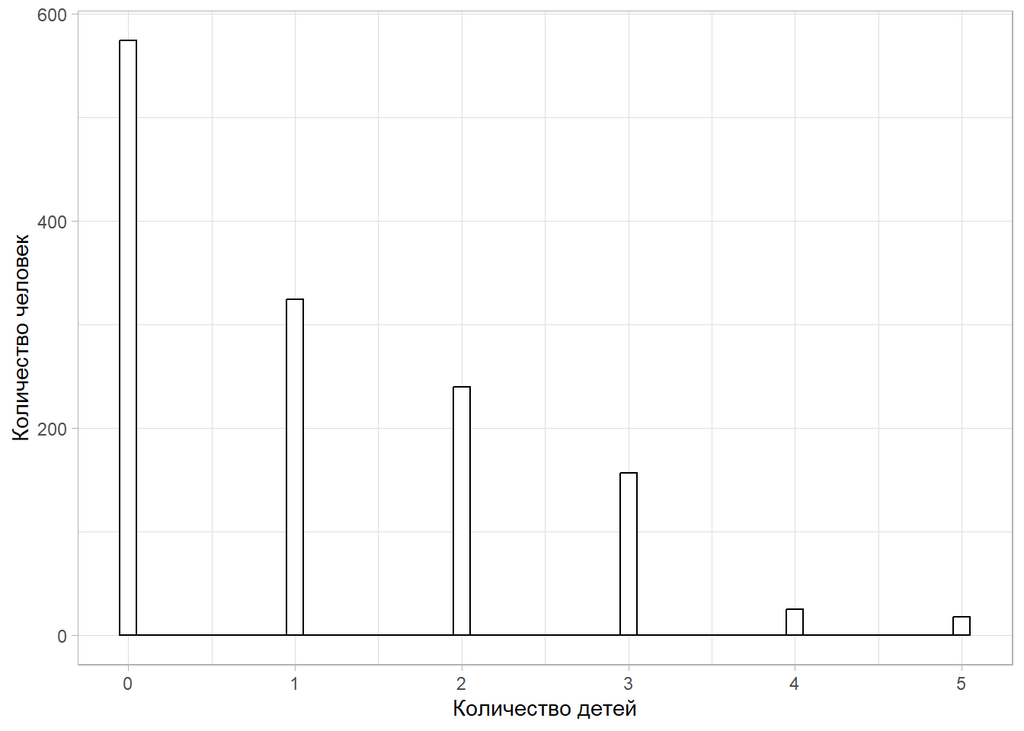

#График плотности Нарисуйте график плотности по колонке charges. Отметьте вертикальные линии средней и медианы на графике. Раскрасьте текст и линии средней и медианы разными цветами. Добавьте текстовые пояснения значения средней и медианы. Подберите тему для графика. Назовите оси.

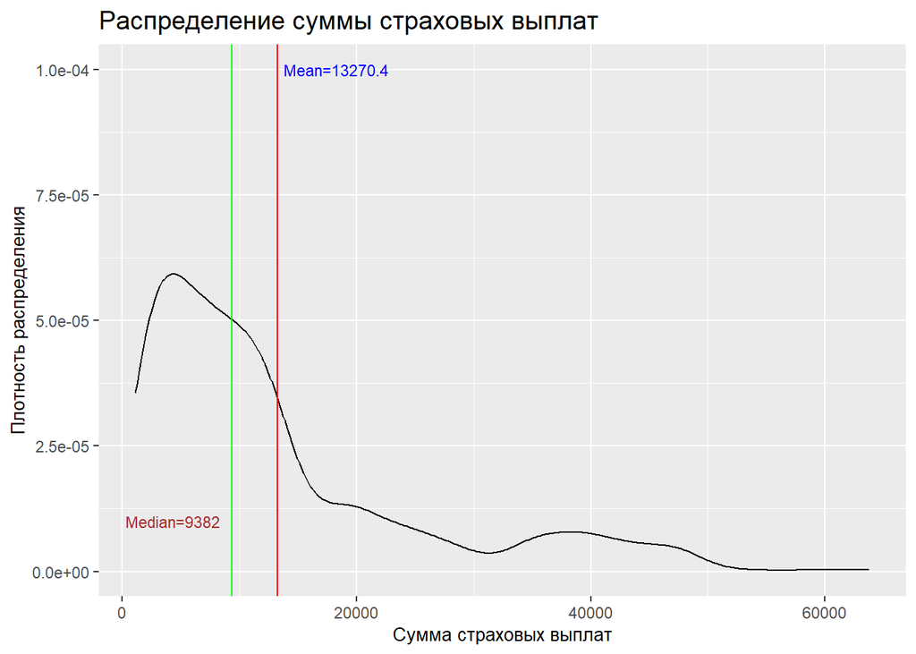

```r
charges_mean <- round(mean(data$charges),1)
charges_median <- round(median(data$charges),1)

ggplot(data = data,
       aes(x = charges)) +
  geom_density()+
  geom_vline(aes(xintercept = charges_mean), color = 'red') +
  annotate("text",
           x = charges_mean+5000,
           y = 0.0001,
           label=paste0("Mean=", charges_mean), color = 'blue', size = 3) +
  geom_vline(aes(xintercept = charges_median), color = 'green') +
  annotate("text",
           x = charges_median-5000,
           y = 0.00001,
           label=paste0("Median=", charges_median), color = 'brown', size = 3)+
  ggtitle('Распределение суммы страховых выплат') +
  labs(y = 'Плотность распределения', x = 'Сумма страховых выплат') +
  theme(
    title = element_text(size = 12),
    axis.title.y = element_text(size=10), axis.title.x = element_text(size=10) )
```

#Бокс-плоты Сделайте три box_plot по отношению переменных charges и (1) sex (2) smoker (3) region. Подберите тему для графика. Назовите оси.

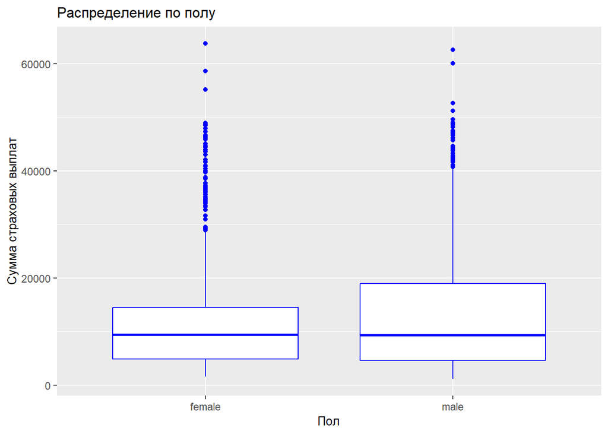

```r
  ggplot() +
  geom_boxplot(data = data,
               aes(x = charges, y = sex), color = 'blue') +
  theme_grey() +
  ggtitle('Распределение по полу') +
  labs(y = 'Пол', x = 'Сумма страховых выплат') +
  theme(
    title = element_text(size = 10),
    axis.title.y = element_text(size=10), axis.title.x = element_text(size=10)

    ) +
  coord_flip()
```

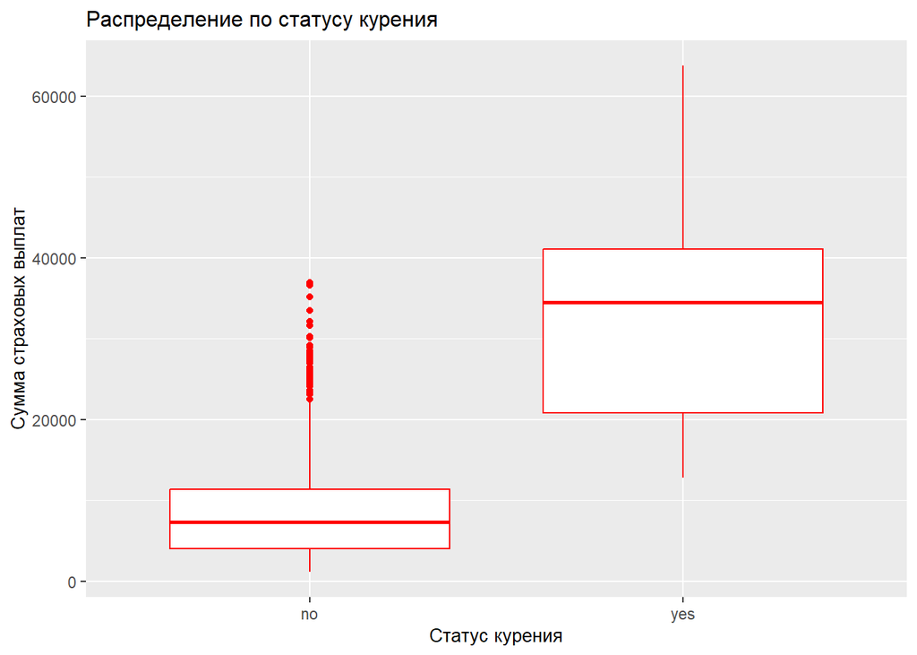

```r
ggplot() +
  geom_boxplot(data = data,
               aes(x = charges, y = smoker), color = 'red') +
  theme_grey() +
  ggtitle('Распределение по статусу курения') +
  labs(y = 'Статус курения', x = 'Сумма страховых выплат') +
  theme(
    title = element_text(size = 10),
    axis.title.y = element_text(size=10), axis.title.x = element_text(size=10)

    ) +
  coord_flip()
```

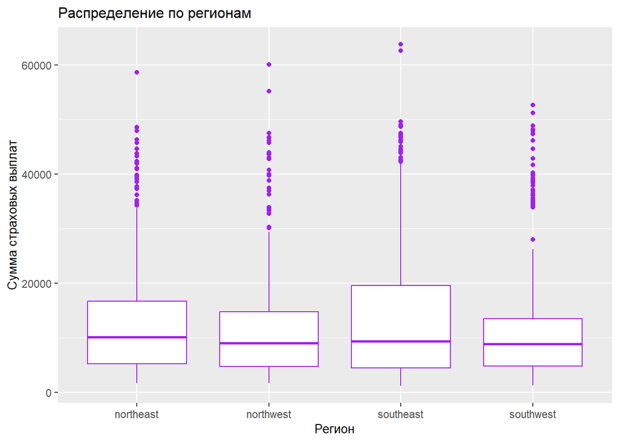

```r
ggplot() +
  geom_boxplot(data = data,
               aes(x = charges, y = region), color = 'purple') +
  theme_grey() +
  ggtitle('Распределение по регионам') +
  labs(y = 'Регион', x = 'Сумма страховых выплат') +
  theme(
    title = element_text(size = 10),
    axis.title.y = element_text(size=10), axis.title.x = element_text(size=10)

    ) +
  coord_flip()
```

#Объединение графиков Объедините графики из заданий 3 и 4 в один так, чтобы сверху шёл один график из задания 3, а под ним 3 графика из задания 4. Сделайте общее название для графика.

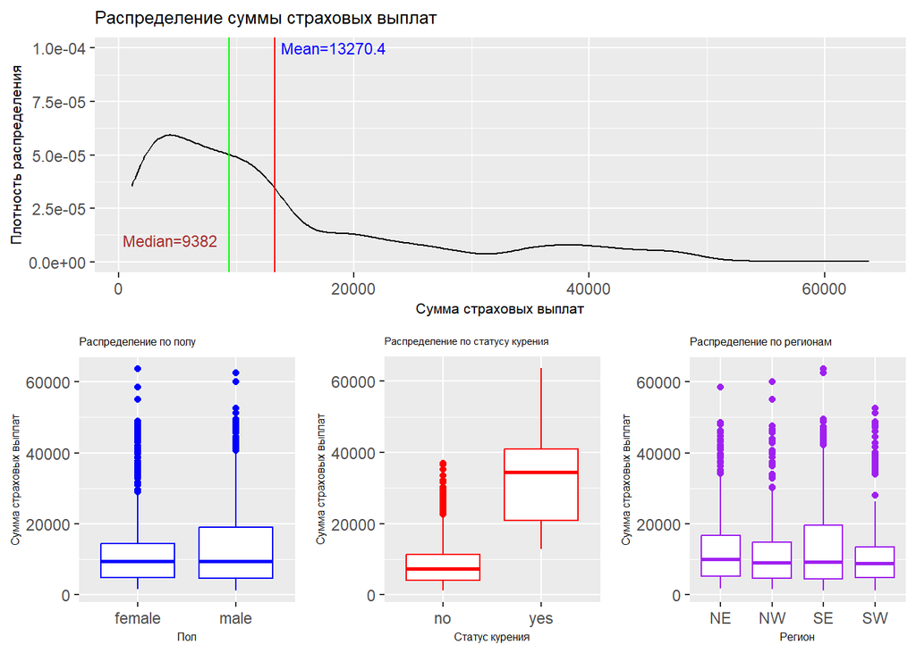

```r
density_plot <- ggplot(data = data,
       aes(x = charges)) +
  geom_density()+
  geom_vline(aes(xintercept = charges_mean), color = 'red') +
  annotate("text",
           x = charges_mean+5000,
           y = 0.0001,
           label=paste0("Mean=", charges_mean), color = 'blue', size = 3) +
  geom_vline(aes(xintercept = charges_median), color = 'green') +
  annotate("text",
           x = charges_median-5000,
           y = 0.00001,
           label=paste0("Median=", charges_median), color = 'brown', size = 3)+
  ggtitle('Распределение суммы страховых выплат') +
  labs(y = 'Плотность распределения', x = 'Сумма страховых выплат') +
  theme(
    title = element_text(size = 8),
    axis.title.y = element_text(size=8), axis.title.x = element_text(size=8) )

sex_plot <- ggplot() +
  geom_boxplot(data = data,
               aes(x = charges, y = sex), color = 'blue') +
  theme_grey() +
  ggtitle('Распределение по полу') +
  labs(y = 'Пол', x = 'Сумма страховых выплат') +
  theme( title = element_text(size = 5),
    axis.title.y = element_text(size=6), axis.title.x = element_text(size=6)

    ) +
  coord_flip()

smoker_plot <- ggplot() +
  geom_boxplot(data = data,
               aes(x = charges, y = smoker), color = 'red') +
  theme_grey() +
  ggtitle('Распределение по статусу курения') +
  labs(y = 'Статус курения', x = 'Сумма страховых выплат') +
  theme( title = element_text(size = 4.8),
    axis.title.y = element_text(size=6), axis.title.x = element_text(size=6)

    ) +
  coord_flip()
data$region <- factor(data$region, labels = c('NE', 'NW', 'SE', 'SW'))
region_plot <- ggplot() +
  geom_boxplot(data = data,
               aes(x = charges, y = region), color = 'purple') +
  theme_grey() +
  ggtitle('Распределение по регионам') +
  labs(y = 'Регион', x = 'Сумма страховых выплат') +
  theme( title = element_text(size = 5),
    axis.title.y = element_text(size = 6), axis.title.x = element_text(size=6)

    ) +
  coord_flip()


#install.packages('ggpubr')
library(ggpubr)
combine_plot <- ggarrange(sex_plot, smoker_plot, region_plot,
                          ncol = 3, nrow = 1)
combine_plot_full <- ggarrange(density_plot, combine_plot,
                          ncol = 1, nrow = 2)



combine_plot_full
```

#Фасет Сделайте фасет графика из задания 3 по колонке region.

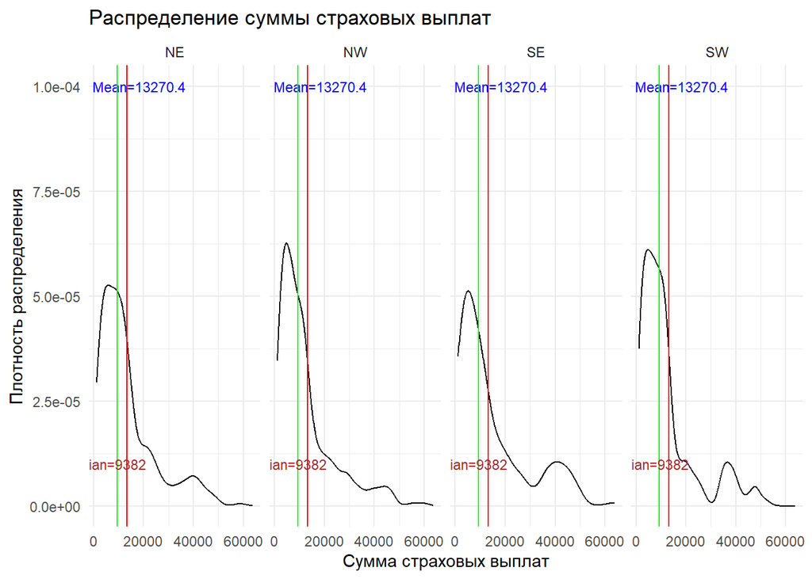

```r
ggplot(data = data,
       aes(x = charges), group = region) +
  geom_density()+
  geom_vline(aes(xintercept = charges_mean), color = 'red') +
  annotate("text",
           x = charges_mean+5000,
           y = 0.0001,
           label=paste0("Mean=", charges_mean), color = 'blue', size = 3) +
  geom_vline(aes(xintercept = charges_median), color = 'green') +
  annotate("text",
           x = charges_median-5000,
           y = 0.00001,
           label=paste0("Median=", charges_median), color = 'brown', size = 3)+
  ggtitle('Распределение суммы страховых выплат') +
  labs(y = 'Плотность распределения', x = 'Сумма страховых выплат') +
  theme(
    title = element_text(size = 12),
    axis.title.y = element_text(size=10), axis.title.x = element_text(size=10) )+
  facet_grid(. ~ region) +
  theme_minimal()
```

#Scatter plot Постройте scatter plot отношения переменных age и charges. Добавьте названия осей, название графика и тему. Сделайте так, чтобы числа по оси Х отображались 14 шрифтом.

[figure not shown]

```r
data %>%
  filter(age != 0 & charges != 0) %>%
  ggplot(aes(x=age, y=charges)) +
    geom_point(size=3, shape = 1)+
  theme_grey() +
  ggtitle('Отношение возраста и суммы выплат') +
  labs(y = 'Возраст', x = 'Сумма страховых выплат')+
  theme(axis.text.x = element_text(size=14))
```

#Линия тренда Добавить линию тренда на предыдущий график

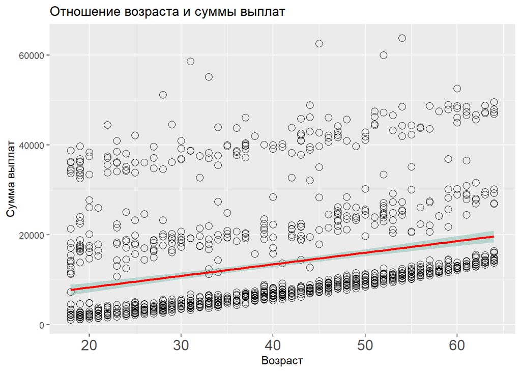

```r
data %>%
  filter(age != 0 & charges != 0) %>%
  ggplot(aes(x=age, y=charges)) +
    geom_point(size=3, shape = 1)+
  geom_smooth(method=lm,
              color="red", fullrange = T,
              fill="#69b3a2",
              se=TRUE)+
  theme_grey() +
  ggtitle('Отношение возраста и суммы выплат') +
  labs(y = 'Сумма выплат', x = 'Возраст')+
  theme(axis.text.x = element_text(size=14))
```

#Разбивка графика по статусу курения

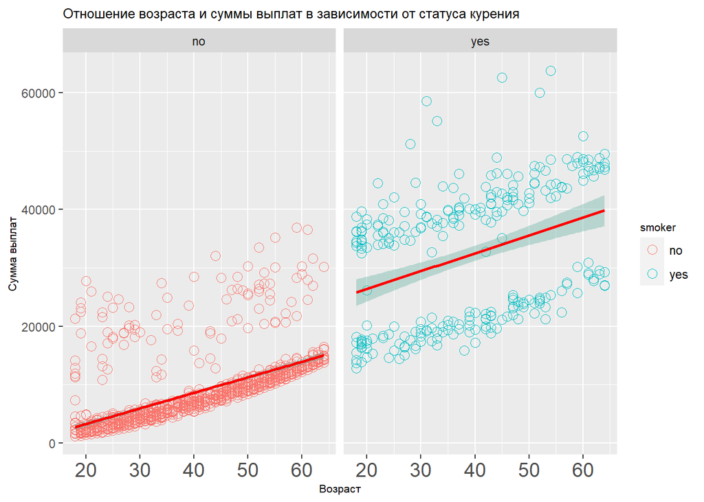

```r
data %>%
  filter(age != 0 & charges != 0) %>%
  ggplot(aes(x=age, y=charges, color = smoker, fill = smoker, group = smoker)) +
    geom_point(size=3, shape = 1)+
  geom_smooth(method=lm,
              color="red", fullrange = T,
              fill="#69b3a2",
              se=TRUE)+
  facet_grid(. ~ smoker)+
  theme_grey() +
  ggtitle('Отношение возраста и суммы выплат в зависимости от статуса курения') +
  labs(y = 'Сумма выплат', x = 'Возраст')+
  theme(title = element_text(size = 8), axis.text.x = element_text(size=14))
```

#То же самое для ИМТ Сделайте график из заданий 7-9, но вместо переменной age используйте переменную bmi.

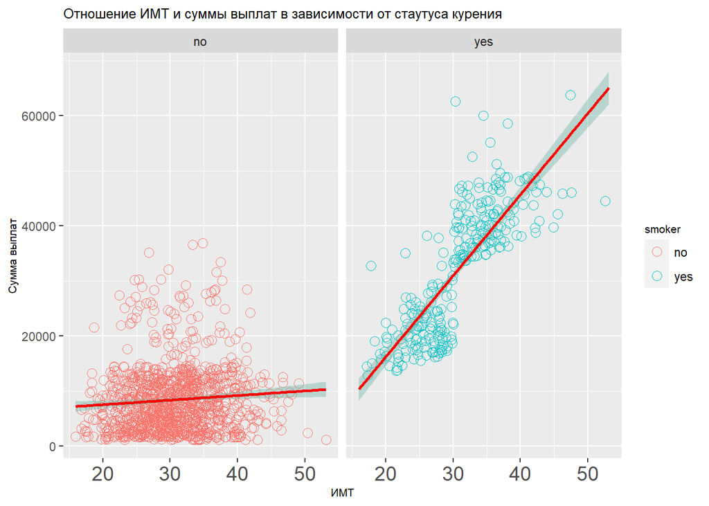

```r
data %>%
  filter(bmi != 0 & charges != 0) %>%
  ggplot(aes(x=bmi, y=charges, color = smoker, fill = smoker, group = smoker)) +
    geom_point(size=3, shape = 1)+
  geom_smooth(method=lm,
              color="red", fullrange = T,
              fill="#69b3a2",
              se=TRUE)+
  facet_grid(. ~ smoker)+
  theme_grey() +
  ggtitle('Отношение ИМТ и суммы выплат в зависимости от стаутуса курения') +
  labs(y = 'Сумма выплат', x = 'ИМТ')+
  theme(title = element_text(size = 8), axis.text.x = element_text(size=14))
```

#Повторение графика из задания 14

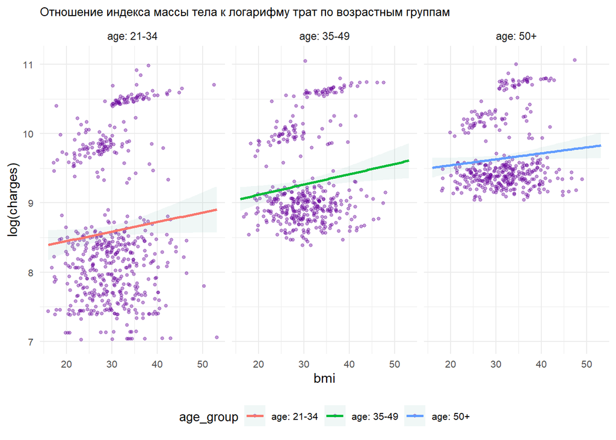

```r
data <- data %>%
  mutate(
    log_charges = log(charges),
    age_group = case_when(
      age < 35 ~ "age: 21-34",
      age >= 35 & age < 50 ~ "age: 35-49",
      age >= 50 ~ "age: 50+"
    ))

data %>%
  filter(bmi != 0 & log_charges != 0) %>%
  ggplot(aes(x=bmi, y=log_charges, color = age_group, fill = age_group, group = age_group)) +
    geom_point(size=1, color = '#660099', alpha = 0.4)+
  geom_smooth(method=lm,
             fullrange = T, fill="#69b3a2", alpha = 0.1,
              se=TRUE)+
  facet_grid(. ~ age_group)+
  theme_minimal() +
  ggtitle('Отношение индекса массы тела к логарифму трат по возрастным группам') +
  labs(y = 'log(charges)', x = 'bmi')+
  theme(title = element_text(size = 8), axis.text.x = element_text(size=8), axis.text.y = element_text(size=8), axis.title.x = element_text(size = 11), axis.title.y = element_text(size = 11), legend.position = 'bottom', legend.text = element_text(size = 8), legend.title = element_text(size = 10))
```

#Вопрос №1 к данным Как распределен ИМТ среди женщин Выбрана гистограмма ИМТ по подвыборке женщин с нанесением на график среднего и медианы для визуализации типа распределения, по графику распределение близко к нормальному

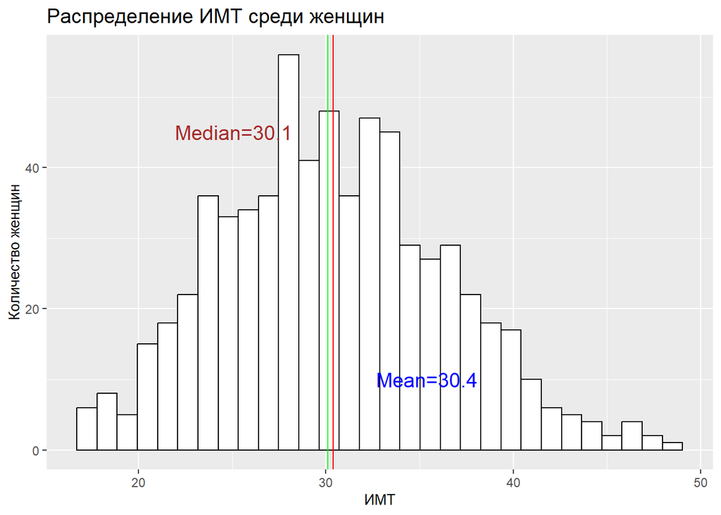

```r
data_fem <- data[data$sex == 'female', ]

bmi_mean <- round(mean(data_fem$bmi),1)
bmi_median <- round(median(data_fem$bmi),1)

ggplot(data = data_fem,
       aes(x = bmi)) +
  geom_histogram(color = 'black', fill = 'white')+
  geom_vline(aes(xintercept = bmi_mean), color = 'red') +
  annotate("text",
           x = bmi_mean+5,
           y = 10,
           label=paste0("Mean=", bmi_mean), color = 'blue', size = 5) +
  geom_vline(aes(xintercept = bmi_median), color = 'green') +
  annotate("text",
           x = bmi_median-5,
           y = 45,
           label=paste0("Median=", bmi_median), color = 'brown', size = 5)+
  ggtitle('Распределение ИМТ среди женщин') +
  labs(y = 'Количество женщин', x = 'ИМТ') +
  theme(
    title = element_text(size = 12),
    axis.title.y = element_text(size=10), axis.title.x = element_text(size=10) )
```

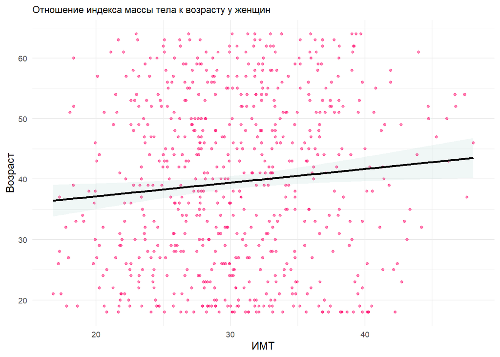

```r
data_fem %>%
  ggplot(aes(x=bmi, y=age)) +
    geom_point(size=1, color = '#FF0066', alpha = 0.5)+
  geom_smooth(method=lm,
             fullrange = T, color = 'black', fill="#69b3a2", alpha = 0.1,
              se=TRUE)+
  theme_minimal() +
  ggtitle('Отношение индекса массы тела к возрасту у женщин') +
  labs(y = 'Возраст', x = 'ИМТ')+
  theme(title = element_text(size = 8), axis.text.x = element_text(size=8), axis.text.y = element_text(size=8), axis.title.x = element_text(size = 11), axis.title.y = element_text(size = 11), legend.position = 'bottom', legend.text = element_text(size = 8), legend.title = element_text(size = 10))
```

#Вопрос к данным №3 Какое количество детей у женщины преобладает в зависимости от возрастной группы Выбраны сгруппированные гистограммы, они позволяют узнать наиболее частое количество детей в каждой возрастной группе (во всех группах <2), и в какой группе какое число детей преобладает (в возрасте 35-49 больше всего женщин с количеством детей 2-4 и >5)

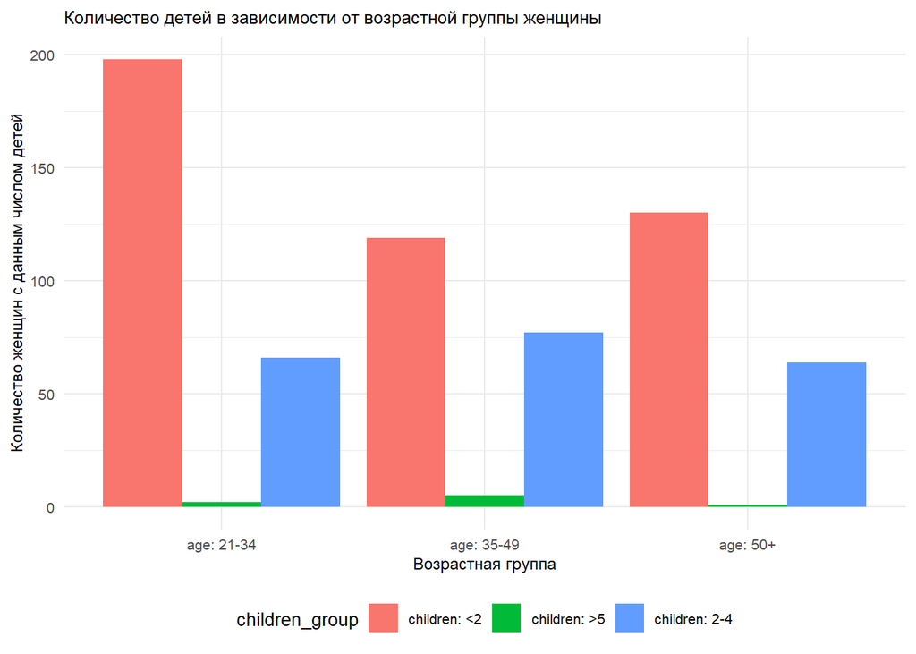

```r
data_fem <- data_fem %>%
  mutate(
    children_group = case_when(
      children < 2 ~ "children: <2",
      children >= 2 & children < 5 ~ "children: 2-4",
      children >= 5 ~ "children: >5"
    ))

ggplot() +
  geom_bar(data = data_fem,
           aes(x = age_group, fill = children_group),
           position="dodge")+
  theme_minimal() +
  ggtitle('Количество детей в зависимости от возрастной группы женщины') +
  labs(y = 'Количество женщин с данным числом детей', x = 'Возрастная группа')+
  theme(title = element_text(size = 8), axis.text.x = element_text(size=8), axis.text.y = element_text(size=8), axis.title.x = element_text(size = 9), axis.title.y = element_text(size = 9), legend.position = 'bottom', legend.text = element_text(size = 8), legend.title = element_text(size = 10))
```